# Effect of Loan Variables on Loan Amount and Loan Status

## by Bayonle Ibukun

## Investigation Overview

I focused on analyzing the relationship between the loan amount and loan status. I also explored how loan term,EmploymentStatus,IncomeRange, Prosper score, and Lenderyield influenced the loan amount and loan status. My aim is to identify what factors determine the loan amount that lenders are willing to grant and what factors influence the fate of the loan.

## Dataset Overview

The dataset contains 103,227 entries and includes 29 distinct features. The analysis is primarily centered on a few key features, including LoanOriginalAmount, loan status, Prosper score, Loan term, Listing Category, Employment State, Income Range, and IsHomeOwner. It should be noted that the dataset has been preprocessed and refined, through the removal of missing or erroneous values, to enhance the reliability and accuracy of the results.

## Loan Amount Distribution

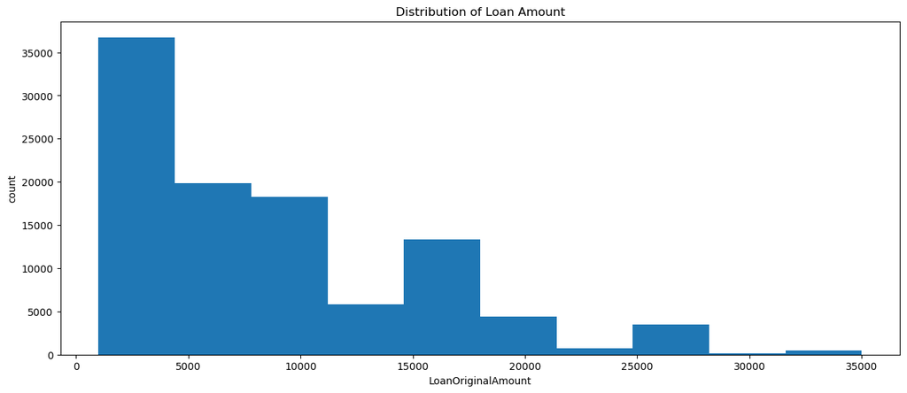

### Loan Staus

Loans that are still active make up the largest portion, with completed loans coming in second.

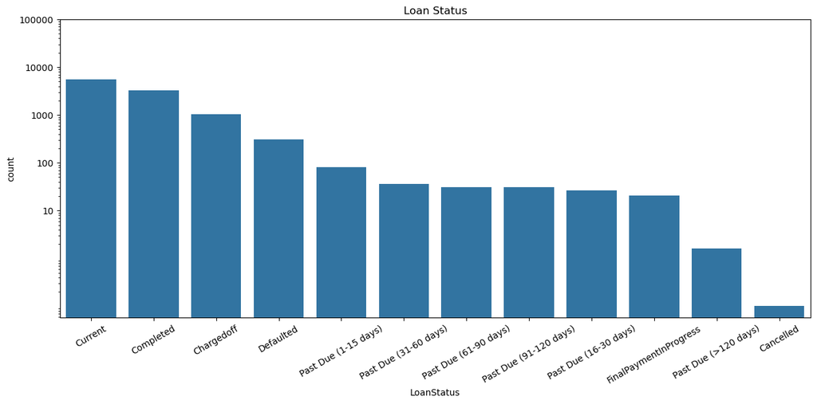

## Loan Amount Distribution, Loan Staus and Term

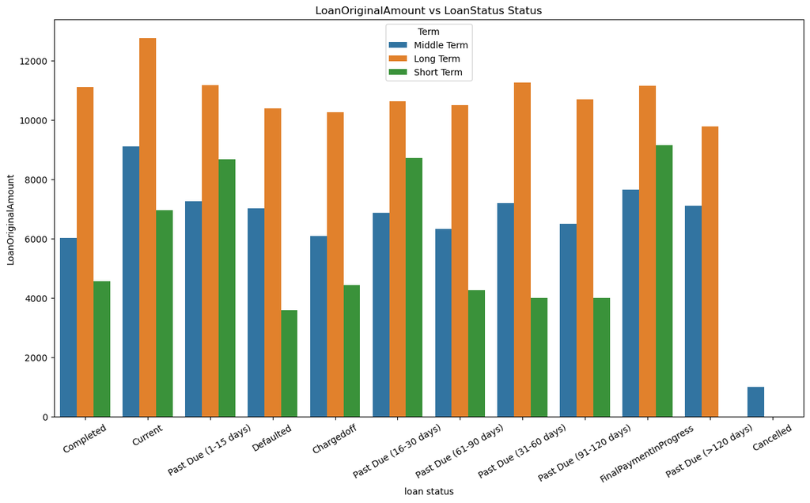

## LoanOriginalAmount, MonthlyLoanPayment and LoanTerm

There is a significant positive correlation between the loan amount and the monthly payment across all types of loans, with a particularly strong association for short-term loans. This indicates that an increase in the loan amount results in a corresponding increase in the monthly payment for short-term loans. Compared to other loan categories, short-term loans are more probable to be paid back, potentially due to their lower loan amounts and higher monthly payments. As a result, borrowers can more quickly satisfy their loan obligations, decreasing the probability of default.

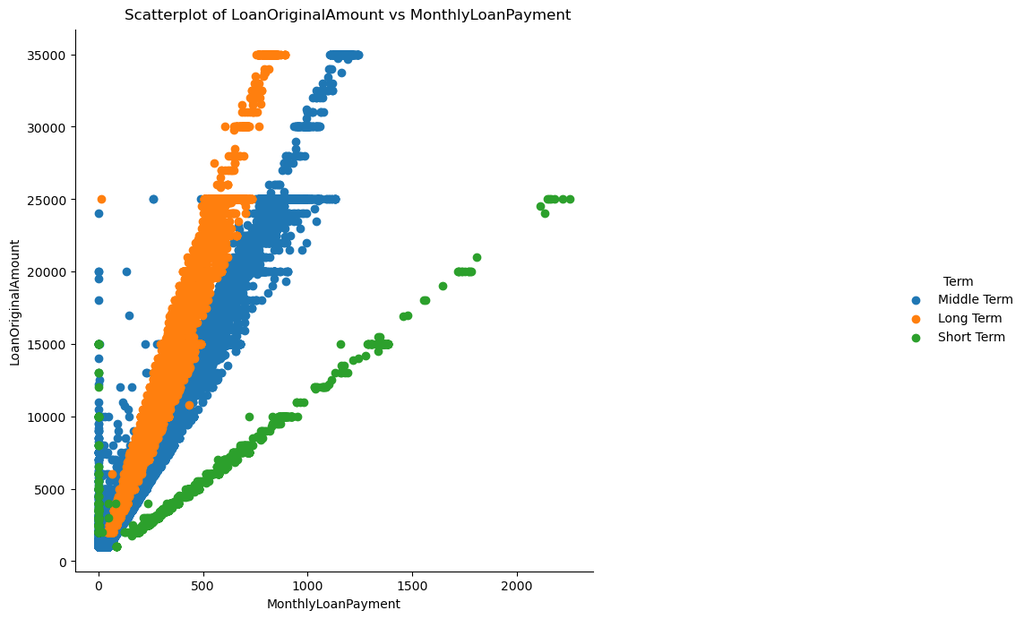

### Relation between ListingCategory & LoanOriginalAmount & Term

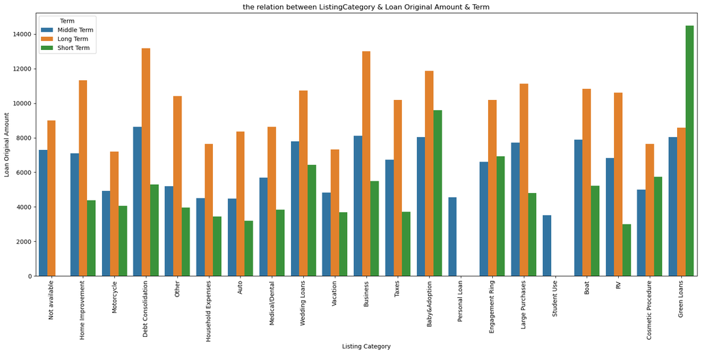

## Loan Original Amount Across Loan Term and Prosper Score

short-term loans typically have smaller loan amounts, and the borrower's ProsperScore rating may not have a significant impact on these loans. Middle-term loans with high ProsperScore ratings are more likely to be approved for larger loan amounts, and long-term loans with high ProsperScore ratings are the most preferred for obtaining the largest loan amounts.

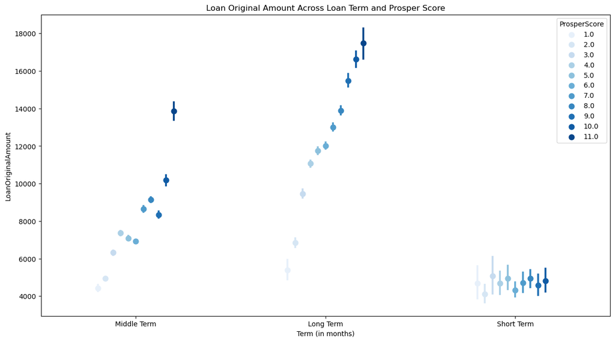

## LoanStatus, LenderYield and EmploymentStatus

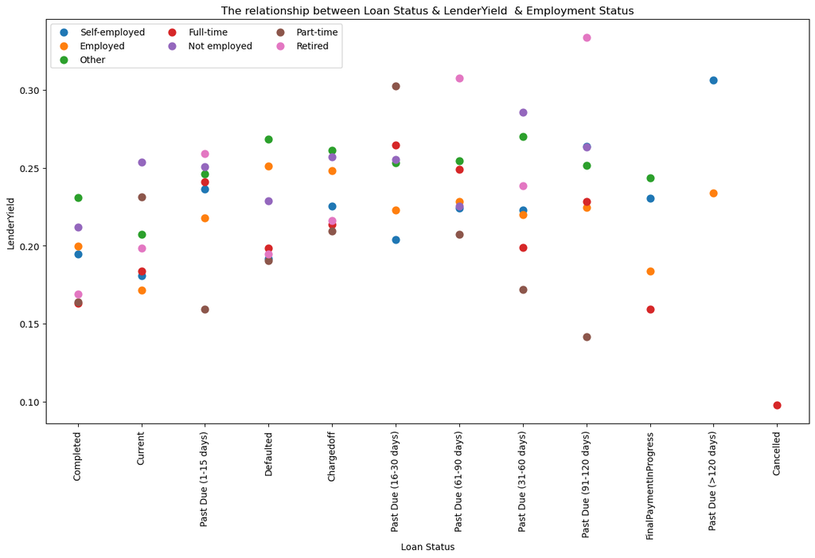

## IncomeRange and LoanOriginalAmount, IsHomeOwner and LoanOriginalAmount

individuals with lower income tend to apply for loans of less than 10,000 dollars, while those with higher income ranges of 50,000 dollars or more are more likely to be approved for higher loan amounts. Additionally, homeowners are more likely to secure higher loan amounts compared to non-homeowners, as non-homeowners mostly get loans under the 10,000 dollar mark.

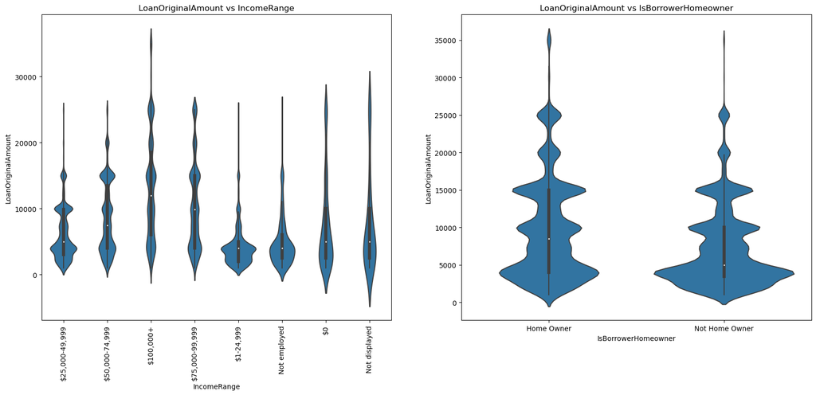